# FP3 Visualization

Wenxuan Zhu

2023-12-08

```r
df <- read_csv("/Users/zhuwenxuan/Desktop/STAT 456/final project/topical_data_cleaned.csv")
df_screener <- read_sas("nsch_2021_screener.sas7bdat")

# How many NA?
n_miss(df) # 5197288
```

```
## [1] 5197288
```

```r
prop_miss(df) # 0.4047034
```

```
## [1] 0.4047034
```

```r
# Which variables are affected?
df %>% is.na() %>% colSums()
```

```
##          ACE_score             FIPSST            STRATUM               HHID
##                  0                  0                  0                  0
##           FORMTYPE          TOTKIDS_R             TENURE         HHLANGUAGE
##                  0                  0                  0                150
##       SC_AGE_YEARS             SC_SEX     K2Q35A_1_YEARS           BIRTH_MO
##                  0                  0              26803                148
##           BIRTH_YR             MOMAGE       K6Q41R_STILL       K6Q42R_NEVER
##                236                496              27797              27797
##       K6Q43R_NEVER             K6Q13A             K6Q13B             K6Q14A
##              27797              27797              27797              27797
##             K6Q14B          K4Q30_R_1          K4Q30_R_2          K4Q30_R_3
##              27797                 67                 67                 67
##        DENTALSERV1        DENTALSERV2        DENTALSERV3        DENTALSERV4
##               3705               3705               3705               3705
##        DENTALSERV5        DENTALSERV6        DENTALSERV7           K4Q28X01
##               3705               3705               3705              26591
##           K4Q28X02           K4Q28X03         K4Q28X_EAR           K4Q28X04
##              26591              26591              26591              26591
##           K4Q28X05          SESPLANYR          SESPLANMO              K4Q37
##              26591              22812              27233              22365
##          SPCSERVMO         LIVEUSA_YR         LIVEUSA_MO            K11Q43R
##              26780              26613              27765                517
##             A1_AGE         A1_LIVEUSA             A2_AGE         A2_LIVEUSA
##                216              23668               5283              24150
##            HHCOUNT           FAMCOUNT          BREATHING         SWALLOWING
##                  0                312                 79                184
##            STOMACH       PHYSICALPAIN              HANDS       COORDINATION
##                216                131              27797              27797
##         TOOTHACHES           GUMBLEED           CAVITIES         MEMORYCOND
##                181                173                 83                113
##         WALKSTAIRS           DRESSING        ERRANDALONE             K2Q43B
##                114                166              13070                137
##          BLINDNESS          ALLERGIES     ALLERGIES_CURR          ARTHRITIS
##                 90                 57              19601                254
##     ARTHRITIS_CURR             K2Q40A             K2Q40B             K2Q61A
##              27676                212              24127                130
##             K2Q61B             K2Q41A             K2Q41B             K2Q42A
##              27716                128              27638                103
##             K2Q42B              HEART         HEART_BORN         HEART_CURR
##              27462                 41              27048              27041
```

[output cut: 177 more lines]

```
##              27797              27797              27797              27797
##    FRSTSOLIDS_MO_S          HOUSE_GEN           FAMILY_R            CURRINS
##              27797                371                140                 57
##             INSGAP            INSTYPE         BIRTHWT_VL          BIRTHWT_L
##                190                419               1025               1025
##            BIRTHWT             FPL_IF        A1_GRADE_IF         BIRTH_YR_F
##               1025                  0                  0                  0
##           SC_ASIAN            SC_AIAN            SC_NHPI           BMICLASS
##                 33                  0                  0               9255
##         HHCOUNT_IF            HIGRADE       HIGRADE_TVIS             FPL_I1
##                  0                  0                  0                  0
##             FPL_I2             FPL_I3             FPL_I4             FPL_I5
##                  0                  0                  0                  0
##             FPL_I6                FWC
##                  0                  0
```

[figure not shown]

```r
# Which variables contain the most missing variables?
gg_miss_var(df, show_pct = TRUE) +
  labs(title = "Look at all the missing ones :(")
```

## Kid’s mental health

```r
# Recode severity levels
df_kid_mental <- df %>%
  select(ACE_score, K2Q31C, K2Q32C, K2Q33C) %>%
  mutate_at(vars(K2Q31C, K2Q32C, K2Q33C), # ADD/ADHD, Depression, Anxiety
    ~ ifelse(. == "1", "Mild",
      ifelse(. == "2", "Moderate",
        ifelse(. == "3", "Severe", NA))))
```

### ADD/ADHD, depression, and anxiety Boxplot

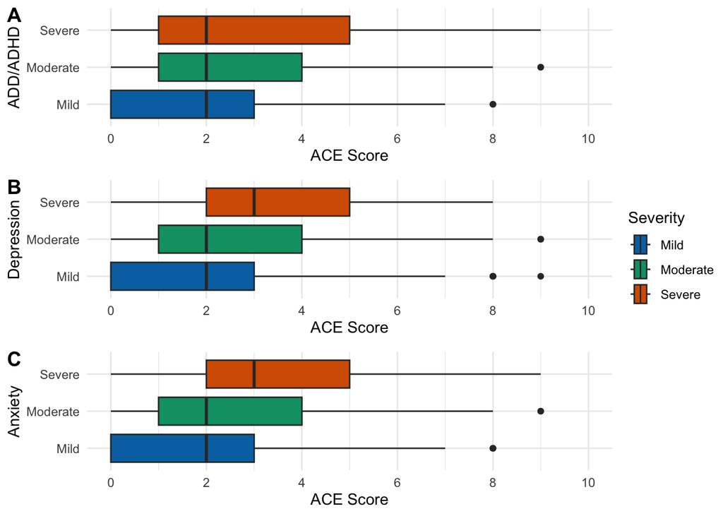

```r
# Define color-blind friendly colors
cb_color <- c("#0072B2", "#009E73", "#D55E00")

# Create the bar plot
add <- df_kid_mental %>%
  na.omit(K2Q31C) %>%
  ggplot(aes(y = K2Q31C, x = ACE_score, fill = K2Q31C)) +
  geom_boxplot() +
  # facet_wrap(~K2Q31C, scales = "free_x", nrow = 1) +  # Facet by mental problem
  scale_fill_manual(values = cb_color) +
  scale_x_continuous(limits = c(0,10), breaks = seq(0, 10, by = 2)) +
  labs(
    y = "ADD/ADHD",
    x = "ACE Score",
    fill = "Severity"
  )

dep <- df_kid_mental %>%
  na.omit(K2Q32C) %>%
  ggplot(aes(y = K2Q32C, x = ACE_score, fill = K2Q32C)) +
  geom_boxplot() +
  # facet_wrap(~K2Q32C, scales = "free_x", nrow = 1) +  # Facet by mental problem
  scale_fill_manual(values = cb_color) +
  scale_x_continuous(limits = c(0,10), breaks = seq(0, 10, by = 2)) +
  labs(
    y = "Depression",
    x = "ACE Score",
    fill = "Severity"
  )

anx <- df_kid_mental %>%
  na.omit(K2Q33C) %>%
  ggplot(aes(y = K2Q33C, x = ACE_score, fill = K2Q33C)) +
  geom_boxplot() +
  # facet_wrap(~K2Q33C, scales = "free_x", nrow = 1) +  # Facet by mental problem
  scale_fill_manual(values = cb_color) +
  scale_x_continuous(limits = c(0,10), breaks = seq(0, 10, by = 2)) +
  labs(
    y = "Anxiety",
    x = "ACE Score",
    fill = "Severity"
  )

ggarrange(add, dep, anx,
          common.legend = TRUE,
          legend = "right",
          labels = c("A", "B", "C"),
          ncol = 1, nrow = 3)
```

The motivation for this visualization is to explore the relationship between the severity of kids’ mental health problems (specifically ADD/ADHD, depression, and anxiety) and their ACE (Adverse Childhood Experiences) scores. ACE scores are a measure of the number of adverse experiences a person had during their childhood, such as abuse, neglect, or household dysfunction. Understanding this relationship is important because it can provide insights into how childhood experiences may be associated with the severity of mental health issues in children.

### Indirect/Unclear factors to ACEs

K2Q35A_1_YEARS: How old was this child when a doctor or other health care provider FIRST told you that they had Autism, ASD, Asperger’s Disorder or PDD? K2Q36A ~ C: development delay K2Q37A ~ C: speech disorder K2Q40A ~ C: Asthma (哮喘) K2Q41A ~ C: diabetes. # no plots feasible K2Q42A ~ C: Epilepsy (癫痫) K2Q60A ~ C: intellectual disability Unclear: CYSTFIB: Has a doctor or other health care provider EVER told you that this child has… Cystic Fibrosis?

```r
df_kid_mental_indirect <- df %>%
  select(ACE_score, K2Q35A_1_YEARS, K2Q36A:K2Q36C, K2Q37A:K2Q37C, K2Q40A:K2Q40C, K2Q41A:K2Q41C, K2Q42A:K2Q42C, K2Q60A:K2Q60C) %>%
  mutate_at(vars(K2Q36C, K2Q37C, K2Q40C, K2Q41C, K2Q42C, K2Q60C),
    ~ ifelse(. == "1", "Mild",
      ifelse(. == "2", "Moderate",
        ifelse(. == "3", "Severe", NA)))) %>%
  mutate_at(vars(K2Q36A, K2Q37A, K2Q40A, K2Q41A, K2Q42A, K2Q60A),
    ~ ifelse(. == "1", "Yes",
      ifelse(. == "2", "No", NA)))

colnames(df_kid_mental_indirect)[which(names(df_kid_mental_indirect) == "K2Q36C")] <- "Development_Delay"
colnames(df_kid_mental_indirect)[which(names(df_kid_mental_indirect) == "K2Q37A")] <- "Speech_Disorder"
colnames(df_kid_mental_indirect)[which(names(df_kid_mental_indirect) == "K2Q60C")] <- "Intellectual_Disability"
colnames(df_kid_mental_indirect)[which(names(df_kid_mental_indirect) == "K2Q41C")] <- "Diabetes"
```

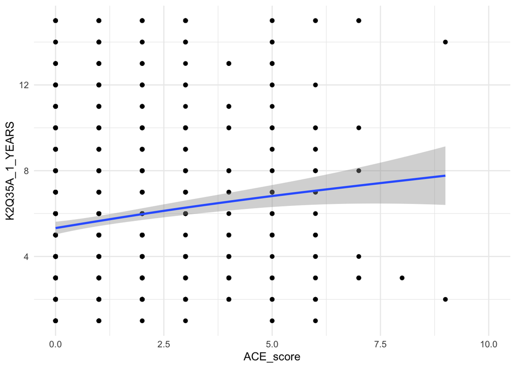

```r
df_kid_mental_indirect %>%
  ggplot(aes(x = ACE_score, y = K2Q35A_1_YEARS))+
  geom_point() +
  geom_smooth()
```

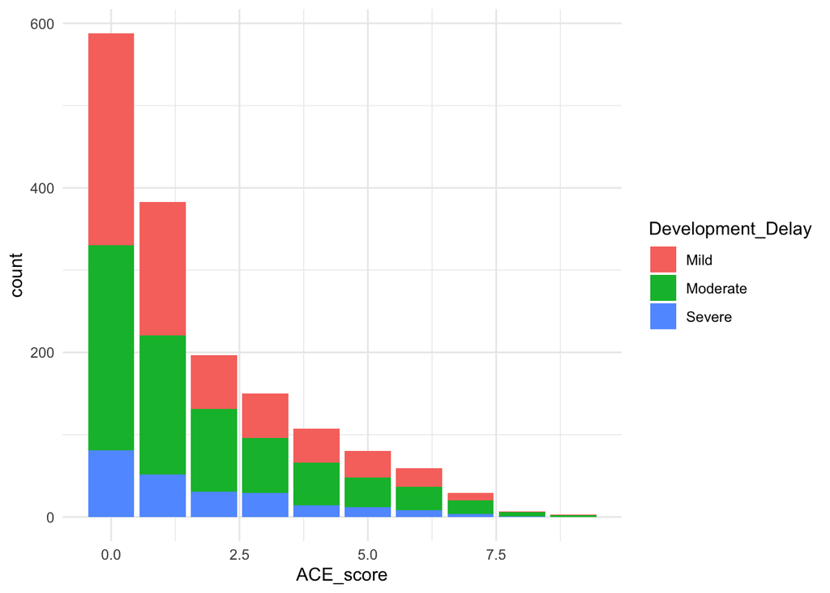

```r
df_kid_mental_indirect %>%
  #filter(ACE_score >3.5 ) %>%
  drop_na(Development_Delay) %>%
  ggplot(aes(x = ACE_score, fill = Development_Delay))+
  geom_bar()
```

```r
cb_color <- c("#0072B2", "#009E73", "#D55E00", "darkgrey")

df_kid_mental_indirect_bar <- df_kid_mental_indirect %>%
  group_by(ACE_score, Development_Delay) %>% # First we'll create counts for each group
  summarise(number_cases = n()) %>%
  group_by(ACE_score) %>% # Group new datafram by class
  mutate(ACE_score_cases = sum(number_cases),
         proportion = number_cases/ACE_score_cases) # Create total counts
```

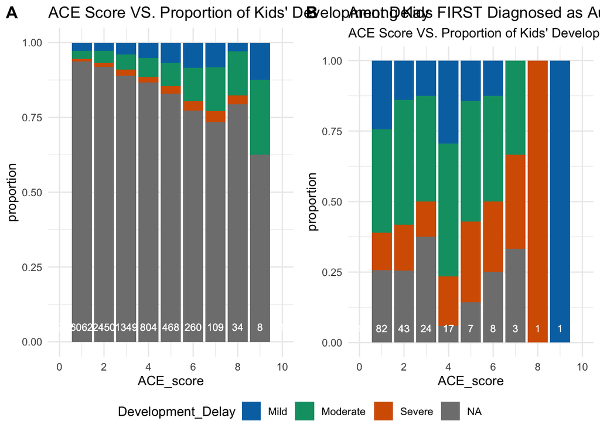

```r
plot_Development_Delay <- df_kid_mental_indirect_bar %>%
  ggplot( aes(x=ACE_score, y=proportion, fill=Development_Delay)) +
  geom_bar(stat="identity", position="stack") +
  geom_text(aes(x=ACE_score, y=0.05, label=ACE_score_cases),
            size=3, colour="white", inherit.aes=FALSE) +
  scale_fill_manual(values = cb_color) +
  scale_x_continuous(limits = c(0,10), breaks = seq(0, 10, by = 2)) +
  labs(title = "ACE Score VS. Proportion of Kids' Development Delay") +
  theme(legend.position = "right")

df_kid_mental_indirect_bar7 <- df_kid_mental_indirect %>%
  filter(K2Q35A_1_YEARS < 4 ) %>%
  group_by(ACE_score, Development_Delay) %>% # First we'll create counts for each group
  summarise(number_cases = n()) %>%
  group_by(ACE_score) %>% # Group new datafram by class
  mutate(ACE_score_cases = sum(number_cases),
         proportion = number_cases/ACE_score_cases) # Create total counts
plot_Development_Delay_Autism <- df_kid_mental_indirect_bar7 %>%
  ggplot( aes(x=ACE_score, y=proportion, fill=Development_Delay)) +
  geom_bar(stat="identity", position="stack") +
  geom_text(aes(x=ACE_score, y=0.05, label=ACE_score_cases),
            size=3, colour="white", inherit.aes=FALSE) +
  scale_fill_manual(values = cb_color) +
  scale_x_continuous(limits = c(0,10), breaks = seq(0, 10, by = 2)) +
  labs(title = "Among Kids FIRST Diagnosed as Autism Under Age 4",
       subtitle = "ACE Score VS. Proportion of Kids' Development Delay") +
  theme(legend.position = "right")

ggarrange(plot_Development_Delay, plot_Development_Delay_Autism,
          common.legend = TRUE,
          legend = "bottom",
          labels = c("A", "B"))
```

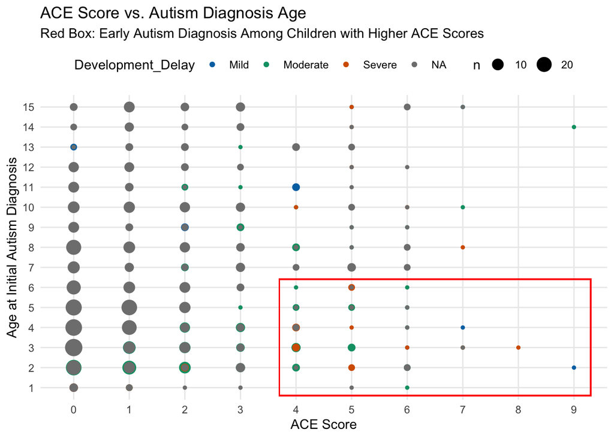

```r
# K2Q35A_1_YEARS: How old was this child when a doctor or other health care provider FIRST told you that they had Autism, ASD, Asperger's Disorder or PDD?
df_kid_mental_indirect %>%
  drop_na(K2Q35A_1_YEARS) %>%
  ggplot(aes(x = factor(ACE_score), y = factor(K2Q35A_1_YEARS), color = Development_Delay)) +
  geom_count() +
  scale_color_manual(values = c("#0072B2", "#009E73", "#D55E00")) +
  labs(x = "ACE Score", y = "Age at Initial Autism Diagnosis") +
  theme_minimal()  +
  theme(legend.position = "right") +
  geom_rect(aes(xmin = 4.7, xmax = 10.3, ymin = 0.6, ymax = 6.4), color = "red",alpha = 0.00) +
  theme(legend.position = "top") +
  labs(title = "ACE Score vs. Autism Diagnosis Age",
       subtitle = "Red Box: Early Autism Diagnosis Among Children with Higher ACE Scores")
```

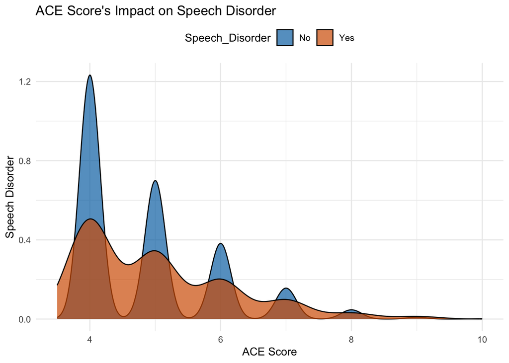

```r
# K2Q37A ~ C: speech disorder
df_kid_mental_indirect %>%
  drop_na(Speech_Disorder) %>%
  filter(ACE_score>= 4) %>%
  ggplot(aes(x = ACE_score, group = Speech_Disorder, fill = Speech_Disorder)) +
  geom_density(alpha = 0.7) +
 # geom_vline(xintercept = 4, color = "#009E73") +
 # annotate("text", x= 7, y = 2.3, label= "Number of kids: 154", color = "#009E73") +
  scale_x_continuous(limits = c(3.5,10), breaks = seq(4, 10, by = 2)) +
  scale_fill_manual(values = c("#0072B2", "#D55E00")) +
  theme(legend.position = "top") +
  labs(x = "ACE Score", y = "Speech Disorder",
       title = "ACE Score's Impact on Speech Disorder")
```

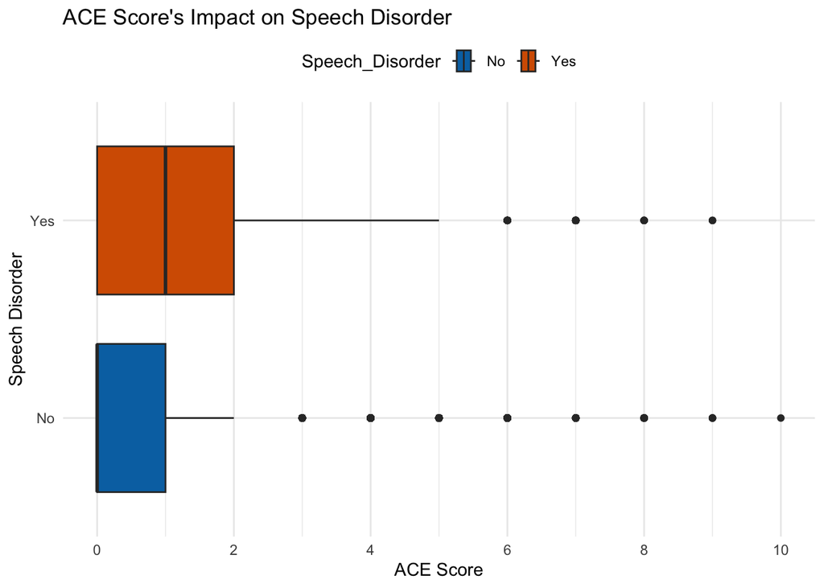

```r
df_kid_mental_indirect %>%
  drop_na(Speech_Disorder) %>%
  ggplot(aes(x = ACE_score, y = Speech_Disorder, group = Speech_Disorder, fill = Speech_Disorder)) +
  geom_boxplot() +
 # geom_vline(xintercept = 4, color = "#009E73") +
 # annotate("text", x= 7, y = 2.3, label= "Number of kids: 154", color = "#009E73") +
  scale_x_continuous(limits = c(0,10), breaks = seq(0, 10, by = 2)) +
  scale_fill_manual(values = c("#0072B2", "#D55E00")) +
  theme(legend.position = "top") +
  labs(x = "ACE Score", y = "Speech Disorder",
       title = "ACE Score's Impact on Speech Disorder")
```

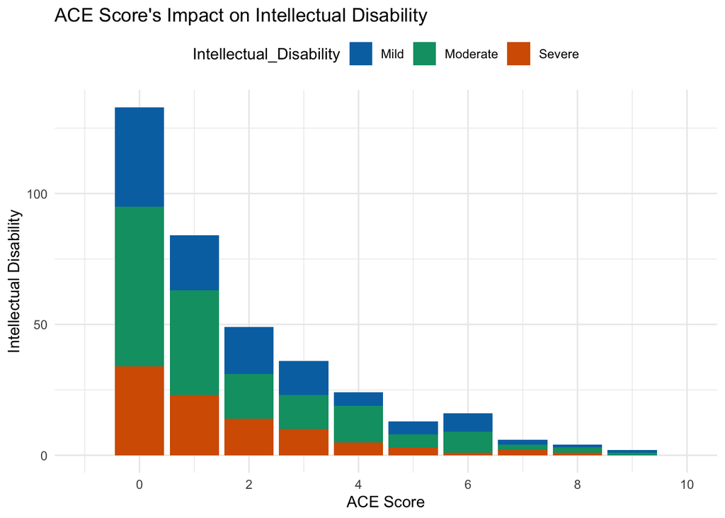

```r
# K2Q60C: intellectual disability
df_kid_mental_indirect %>%
  filter(!is.na(Intellectual_Disability)) %>%
  ggplot(aes(x = ACE_score, fill = Intellectual_Disability)) +
  geom_bar() +
  scale_x_continuous(limits = c(-1,10), breaks = seq(0,10, by = 2)) +
  scale_fill_manual(values = c("#0072B2", "#009E73", "#D55E00")) +
  theme(legend.position = "top") +
  labs(x = "ACE Score", y = "Intellectual Disability",
       title = "ACE Score's Impact on Intellectual Disability")
```

## Kids physical health:

### Preventive_Dental_Visit

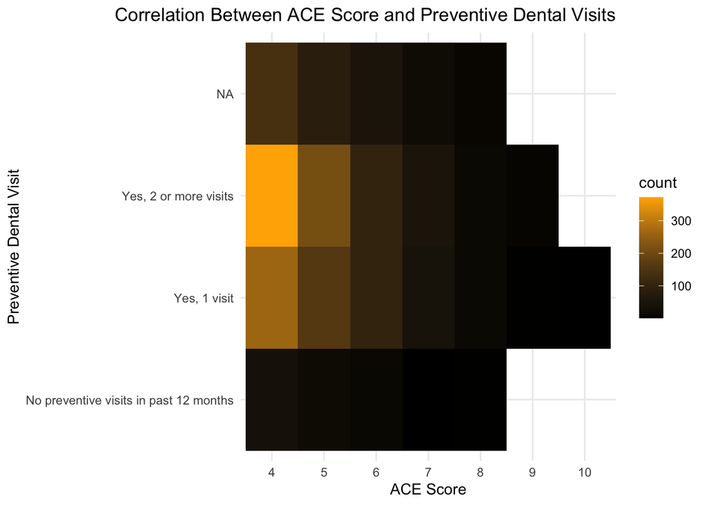

```r
df_kid_physical <- df %>%
  select(ACE_score, DENTISTVISIT) %>%
  mutate_at(vars(DENTISTVISIT),
    ~ ifelse(. == "1", "No preventive visits in past 12 months",
      ifelse(. == "2", "Yes, 1 visit",
        ifelse(. == "3", "Yes, 2 or more visits", NA))))

colnames(df_kid_physical)[which(names(df_kid_physical) == "DENTISTVISIT")] <- "Preventive_Dental_Visit"

# Replace NA values in ACE_score with 0
df_kid_physical <- df_kid_physical %>%
  mutate(ACE_score = ifelse(is.na(ACE_score), 0, ACE_score))

# Create a 2D histogram
df_kid_physical %>%
  filter(ACE_score >= 4)%>%
  ggplot(aes(x = factor(ACE_score), y = Preventive_Dental_Visit)) +
  geom_bin2d() +
  scale_fill_gradient(low = "#000000", high = "#FFB000") +
  labs(x = "ACE Score", y = "Preventive Dental Visit",
       title = "Correlation Between ACE Score and Preventive Dental Visits") +
  theme_minimal() +
  theme(plot.title = element_text(hjust = 1))
```

## Kids’ behavior:

- BULLIED_R：Bullied, Picked On, or Excluded by Others
- BULLY：bully others
- ERRANDALONE: Does this child have any of the following? Difficulty doing errands alone such as visiting a doctor’s office or shopping, because of a physical, mental, or emotional condition
- HCABILITY: DURING THE PAST 12 MONTHS, how often have this child’s health conditions or problems affected their ability to do things other children their same age do?
- HCEXTENT: To what extent do this child’s health conditions or problems affect their ability to do things?
- DISTRACTED: How often is this child easily distracted?

```r
df_kid_behavior <- df %>%
  select(ACE_score, BULLIED_R, BULLY, ERRANDALONE, HCABILITY, HCEXTENT, DISTRACTED) %>%
  mutate_at(vars(BULLIED_R, BULLY),
    ~ case_when(
      . == "1" ~ "Never (in the past 12 months)",
      . == "2" ~ "1-2 times (in the past 12 months)",
      . == "3" ~ "1-2 times per month",
      . == "4" ~ "1-2 times per week",
      . == "5" ~ "Almost every day",
      TRUE ~ as.character(.))) %>%
  mutate_at(vars(ERRANDALONE),
    ~ case_when(
      . == "1" ~ "Yes",
      . == "2" ~ "No",
      TRUE ~ as.character(.))) %>%
  mutate_at(vars(HCABILITY),
    ~ case_when(
      . == "1" ~ "No health condition",
      . == "2" ~ "Never",
      . == "3" ~ "Sometimes",
      . == "4" ~ "Usually",
      . == "5" ~ "Always",
      TRUE ~ as.character(.))) %>%
  mutate_at(vars(HCEXTENT),
    ~ case_when(
      . == "1" ~ "Very little",
      . == "2" ~ "Somewhat",
      . == "3" ~ "A great deal",
      TRUE ~ as.character(.))) %>%
  mutate_at(vars(DISTRACTED),
    ~ case_when(
      . == "1" ~ "Always",
      . == "2" ~ "Most of the time",
      . == "3" ~ "About half the time",
      . == "4" ~ "Sometimes",
      . == "5" ~ "Never",
      TRUE ~ as.character(.)))

colnames(df_kid_behavior)[which(names(df_kid_behavior) == "BULLIED_R")] <- "Bullied_by_others"
colnames(df_kid_behavior)[which(names(df_kid_behavior) == "BULLY")] <- "Bully_others"
colnames(df_kid_behavior)[which(names(df_kid_behavior) == "ERRANDALONE")] <- "Difficulty_Doing_Errands_Alone"
colnames(df_kid_behavior)[which(names(df_kid_behavior) == "HCABILITY")] <- "Health_Affected_Ability"
colnames(df_kid_behavior)[which(names(df_kid_behavior) == "HCEXTENT")] <- "Health_Affected_Ability_Extent"
colnames(df_kid_behavior)[which(names(df_kid_behavior) == "HCABILITY")] <- "Health_Affected_Ability_Often"
```

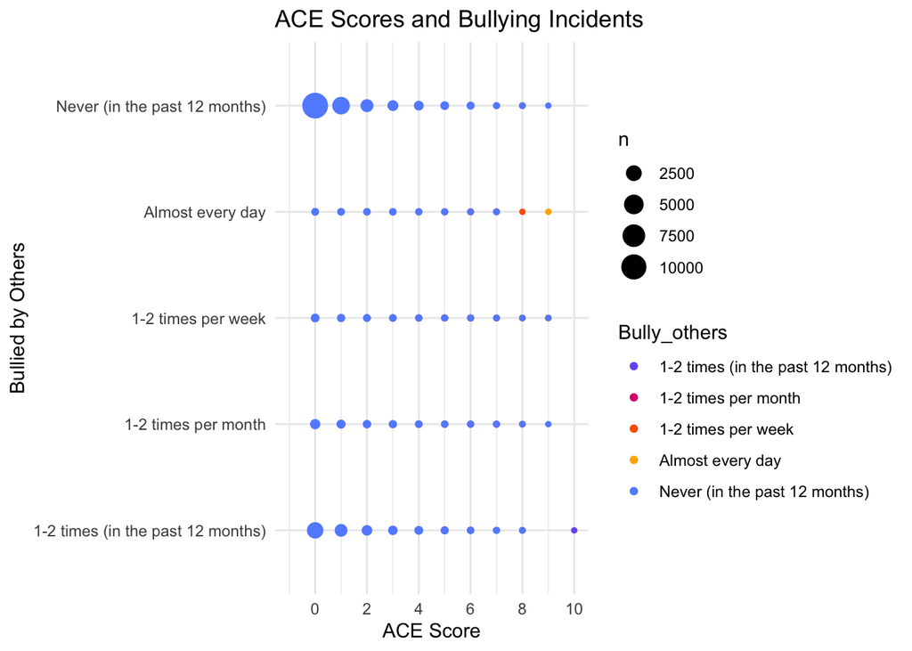

```r
# Bullied_by_others & Bully_others
df_kid_behavior %>%
  drop_na(Bullied_by_others, Bully_others) %>%
  ggplot(aes(x = ACE_score, y = Bullied_by_others, color = Bully_others)) +
  geom_count() +
  scale_x_continuous(limits = c(-1,10), breaks = seq(0,10, by = 2)) +
  scale_color_manual(values = c(
    "Never (in the past 12 months)" = "#648FFF",
    "1-2 times (in the past 12 months)" = "#785EF0",
    "1-2 times per month" = "#DC267F",
    "1-2 times per week" = "#FE6100",
    "Almost every day" = "#FFB000")) +
  labs(x = "ACE Score", y = "Bullied by Others",
       title = "ACE Scores and Bullying Incidents") +
  theme_minimal()
```

```r
# Health_Affected_Ability & Health_Affected_Ability_Extent & Health_Affected_Ability_Often

# Health_Affected_Ability_Extent
df_kid_behavior_bar <- df_kid_behavior %>%
  drop_na(Health_Affected_Ability_Extent) %>%
 # filter(ACE_score >= 4) %>%
  group_by(ACE_score, Health_Affected_Ability_Extent) %>% # First we'll create counts for each group
  summarise(number_cases = n()) %>%
  group_by(ACE_score) %>% # Group new datafram by class
  mutate(ACE_score_cases = sum(number_cases),
         proportion = number_cases/ACE_score_cases) # Create total count
```

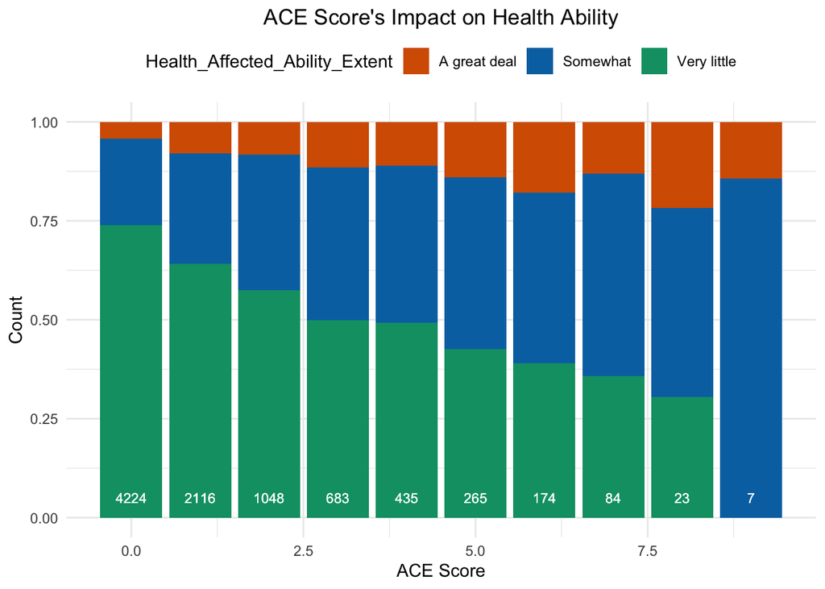

```r
df_kid_behavior_bar %>%
  ggplot(aes(x = ACE_score, y=proportion, fill = Health_Affected_Ability_Extent)) +
  geom_bar(stat="identity", position="stack") +
  geom_text(aes(x=ACE_score, y=0.05, label=ACE_score_cases),
            size=3, colour="white", inherit.aes=FALSE) +
  # facet_wrap(~Health_Affected_Ability) +
  scale_fill_manual(values = c( "#D55E00","#0072B2", "#009E73")) +
  #scale_x_continuous(limits = c(3.5,10), breaks = seq(4,10, by = 2)) +
  labs(x = "ACE Score", y = "Count",
       title = "ACE Score's Impact on Health Ability")  +
  theme(legend.position = "top") +
  theme(plot.title = element_text(hjust = 0.5))
```

```r
# Health_Affected_Ability
df_kid_behavior_bar <- df_kid_behavior %>%
  drop_na(Health_Affected_Ability) %>%
 # filter(ACE_score >= 4) %>%
  group_by(ACE_score, Health_Affected_Ability) %>% # First we'll create counts for each group
  summarise(number_cases = n()) %>%
  group_by(ACE_score) %>% # Group new datafram by class
  mutate(ACE_score_cases = sum(number_cases),
         proportion = number_cases/ACE_score_cases) # Create total count
```

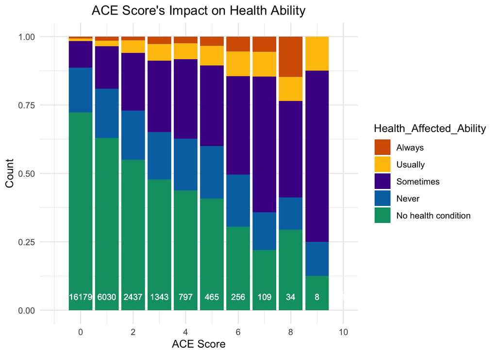

```r
# Define the desired order for the legend
new_order <- c("Always", "Usually", "Sometimes", "Never", "No health condition")

# Reorder the levels of Health_Affected_Ability
df_kid_behavior_bar <- df_kid_behavior_bar %>%
  mutate(Health_Affected_Ability = factor(Health_Affected_Ability, levels = new_order))

# Plotting
df_kid_behavior_bar %>%
  ggplot(aes(x = ACE_score, y = proportion, fill = Health_Affected_Ability)) +
  geom_bar(stat = "identity", position = "stack") +
  geom_text(aes(x = ACE_score, y = 0.05, label = ACE_score_cases),
            size = 3, colour = "white", inherit.aes = FALSE) +
  scale_fill_manual(values = c("#D55E00", "#FFC20A", "#4B0092", "#0072B2", "#009E73")) +
  scale_x_continuous(limits = c(-1, 10), breaks = seq(0, 10, by = 2)) +
  labs(x = "ACE Score", y = "Count",
       title = "ACE Score's Impact on Health Ability")  +
  theme(legend.position = "right") +
  theme(plot.title = element_text(hjust = 0.5))
```